# Лекция 4. Регрессия как каузальный инструмент

Блок 1. Отбор по наблюдаемым

Карен Аванесян

Каузальный анализ в R на данных RLMS-HSE

# Зачем

## Регрессия — рабочая лошадь, а не волшебная палочка

- 90 % прикладных оценок эффектов — регрессия с контролями. Это нормально, **если** мы понимаем, что она делает
- Регрессия реализует backdoor-корректировку (лекция 3): сравнивает людей **с одинаковыми** $X$ и усредняет
- Два вопроса на сегодня: **что именно** усредняет регрессия и **насколько точно** мы это измеряем

Допущение — условная независимость при данных $X$. Регрессия его не проверяет и не создаёт. Она лишь аккуратно (или не очень) усредняет сравнения внутри групп.

## План занятия

1. Что делает «контроль»: теорема Фриша–Во–Ловелла руками
2. Какие сравнения регрессия взвешивает сильнее
3. Формула пропущенной переменной: куда смещена оценка
4. Интерпретация: логарифмы, категории, взаимодействия
5. Стандартные ошибки: робастные и кластерные
6. Инструменты: `fixest`, `marginaleffects`, `modelsummary`

# Идея

## Что такое «при прочих равных»

Регрессия $Y = \alpha + \tau D + X\beta + \varepsilon$ оценивает $\tau$ так (теорема **Фриша–Во–Ловелла**):

**Регрессируем $D$ на $X$**, берём остатки $\tilde D$ — часть $D$, **не объяснённая** контролями

**Регрессируем $Y$ на $X$**, берём остатки $\tilde Y$

**$\hat\tau$** = наклон регрессии $\tilde Y$ на $\tilde D$

Коэффициент при $D$ использует только ту вариацию $D$, которая **остаётся после** контролей. Если $X$ объясняет $D$ почти полностью, оценка опирается на крохи — и на людей, «нетипичных» для своих $X$.

## Какие сравнения весят больше

Если эффект разный в разных группах $X = x$, регрессия с «насыщенными» контролями даёт **взвешенное среднее** эффектов по группам с весами

$$w_x \propto n_x \cdot \text{Var}(D \mid X = x)$$

- Больше веса — группам, где воздействие **варьирует** (половина с дипломом, половина без)
- Группы, где почти у всех диплом есть (или нет), почти не влияют на оценку
- Поэтому регрессионный коэффициент — не ATE и не ATT, а «ATE с регрессионными весами». Мэтчинг и взвешивание (лекции 5–6) меняют веса явно

## Формула пропущенной переменной

Истинная модель: $Y = \tau D + \gamma U + \varepsilon$. Оценили без $U$:

$$\hat\tau_{\text{короткая}} \;\to\; \tau + \gamma \cdot \delta, \qquad \delta = \text{коэффициент в регрессии } U \text{ на } D \mid X$$

- Смещение = (влияние пропущенного на $Y$) × (его связь с $D$)
- **Знак** смещения можно рассуждать: способности повышают зарплату ($\gamma > 0$) и чаще у дипломированных ($\delta > 0$) → отдача от образования **завышена**
- Если пропущенное не связано с $D$ при данных $X$ ($\delta = 0$) — смещения нет, даже если оно сильно влияет на $Y$
- Эта же формула — основа анализа чувствительности (лекция 17)

## Как читать коэффициенты

| Спецификация | Коэффициент означает |
| --- | --- |
| $Y \sim D$, $Y$ в уровнях | разница в рублях |
| $\log Y \sim D$ | ≈ доля: $e^{\tau} - 1$; при $\tau = 0.3$ это 35 %, а не 30 % |
| $\log Y \sim \log X$ | эластичность |
| $Y \sim D + D \times \text{female}$ | эффект для мужчин и **добавка** для женщин |
| $Y \sim \text{i(educ\_level)}$ | разница с базовой категорией, без допущения о линейности |
| $Y \sim D \mid \text{year}$ | сравнение **внутри** года (фиксированные эффекты) |

`marginaleffects::avg_slopes()` и `avg_comparisons()` переводят любую спецификацию в понятные величины: «средний эффект +1 года обучения в процентах зарплаты, отдельно по полу».

## Стандартные ошибки

гетероскедастичность

Дисперсия ошибок разная у разных людей → робастные ошибки (HC1–HC3). В больших выборках — всегда

кластеры

Наблюдения внутри площадки / человека / фирмы коррелированы → кластерные ошибки. Правило: кластеризуем по уровню, на котором **назначается воздействие** или **отбирается выборка**

панель RLMS

`cluster = ~idind` — человек наблюдается много раз; для региональных политик — `cluster = ~psu` или по субъекту

мало кластеров

Меньше 30–40 кластеров — ошибки занижены: wild cluster bootstrap (`fwildclusterboot`)

Стандартная ошибка — это ответ на вопрос «что изменится, если повторить *выборку*». Она ничего не говорит о смещении.

# Код

## Уравнение Минцера на RLMS

```r
m_mincer <- feols(log_wage ~ years_educ + experience + exp2 + female | year,
                  data = work, cluster = ~psu)
etable(m_mincer, depvar = FALSE)
```

|  | m_mincer |
| --- | --- |
| years_educ | 0.072*** (0.006) |
| experience | 0.020*** (0.002) |
| exp2 | -0.0005*** (4.63e-5) |
| female | -0.441*** (0.013) |
| _______________ | ____________________ |
| S.E.: Clustered | by: psu |
| Observations | 79,068 |
| R2 | 0.16 |

0.072 log-пунктов за год обучения

-0.441 женщины, log-пункты

79 068 наблюдений в выборке

Год обучения «даёт» ≈ 7–8 % зарплаты, опыт — выпуклый профиль, женщины получают на ≈ 35 % меньше. Классическая таблица — и ни один коэффициент пока не причинный.

## Как читать вывод `summary()` модели `feols`

- Вывод R
- С пояснениями

```
OLS estimation, Dep. Var.: log_wage
Observations: 79,068
Fixed-effects: year: 13
Standard-errors: Clustered (psu)
            Estimate Std. Error t value            Pr(>|t|)
years_educ  0.071573   0.006432   11.13 0.00000000000023026 ***
experience  0.020015   0.002040    9.81 0.00000000000765240 ***
exp2       -0.000497   0.000046  -10.75 0.00000000000062300 ***
female     -0.441156   0.013373  -32.99           < 2.2e-16 ***
RMSE: 0.629142     Adj. R2: 0.161471
                 Within R2: 0.143358
```

1 · шапка

**OLS**, зависимая, **Observations** — 79 068. **Fixed-effects: year: 13** — число уровней FE: лет 2013–2025, хотя фильтр `year >= 2010` (`experience` есть только с 2013 г.)

2 · Standard-errors

**Clustered (psu)**: 38 кластеров. p-value считается по t-распределению с G − 1 степенями свободы, а не по N

3 · Estimate, Std. Error

Лог-пункты на единицу $X$: год обучения 0.072 ≈ +7.4 %. `exp2` — квадрат опыта: читается вместе с `experience`

4 · t value, Pr(>|t|)

t = Estimate / Std. Error. Длинные строки нулей в p — эффект `scipen = 999`, это «меньше 0.000000001»

5 · RMSE и R²

**Adj. R2** — вместе с эффектами года; **Within R2** — доля разброса, которую объясняют регрессоры **после** вычитания эффектов года (0.143)

6 · сигналы беды

Число уровней FE не совпадает с ожидаемым; `Standard-errors: IID`; NOTE об удалённых наблюдениях или коллинеарных переменных (в курсе заметки выключены — сверяйте N)

## FWL руками

```r
work_r <- work |> mutate(
  y_res = resid(feols(log_wage ~ experience + exp2 + female | year, data = work)),
  d_res = resid(feols(years_educ ~ experience + exp2 + female | year, data = work)))

c(`регрессия с контролями` = coef(m_mincer)["years_educ"],
  `остатки на остатки`     = coef(feols(y_res ~ d_res, data = work_r))["d_res"])
```

```
регрессия с контролями.years_educ          остатки на остатки.d_res
                           0.0716                            0.0716
```

Коэффициенты совпадают в точности. «Контроль» = «вычесть из $D$ и $Y$ всё, что объясняют $X$, и сравнить остатки».

## FWL глазами: binscatter остатков

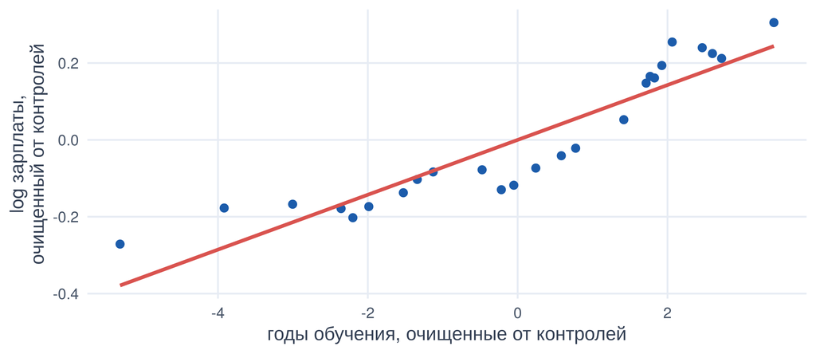

```r
work_r |>
  mutate(bin = ntile(d_res, 25)) |>
  group_by(bin) |> summarise(d = mean(d_res), y = mean(y_res)) |>
  ggplot(aes(d, y)) + geom_point(size = 2.5, colour = pal["indigo"]) +
  geom_smooth(method = "lm", se = FALSE, colour = pal["coral"]) +
  labs(x = "годы обучения, очищенные от контролей", y = "log зарплаты,\nочищенный от контролей")
```

## Путь коэффициента

- Результат
- Код

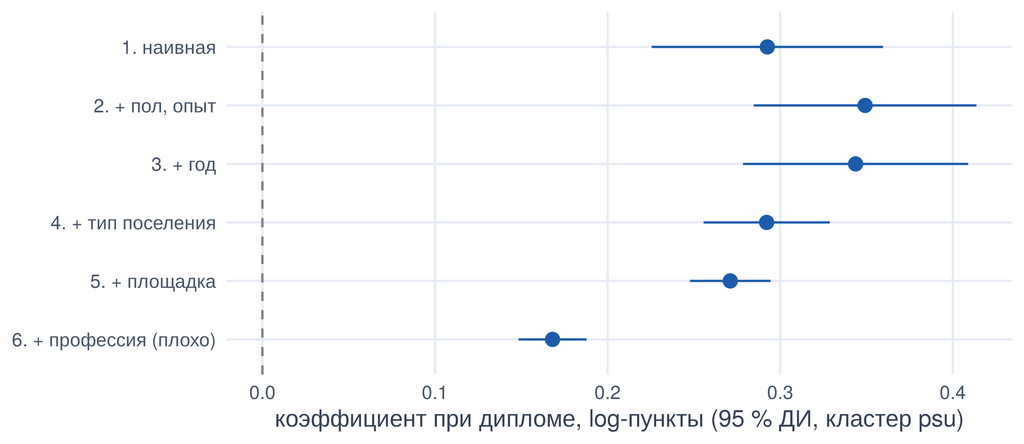

```r
d_ed <- work |> mutate(higher_ed = as.integer(educ_level == "Высшее"))
spec <- function(fe = NULL) as.formula(paste(
  "log_wage ~ higher_ed + female + experience + exp2", if (!is.null(fe)) paste("|", fe)))
models <- list(
  "1. наивная"             = feols(log_wage ~ higher_ed, d_ed),
  "2. + пол, опыт"         = feols(spec(), d_ed),
  "3. + год"               = feols(spec("year"), d_ed),
  "4. + тип поселения"     = feols(spec("year + settlement"), d_ed),
  "5. + площадка"          = feols(spec("year + settlement + site"), d_ed),
  "6. + профессия (плохо)" = feols(spec("year + settlement + site + occup_group"), d_ed)
)
path <- imap_dfr(models, ~ tidy(.x, conf.int = TRUE, vcov = ~psu) |>
                   filter(term == "higher_ed") |> mutate(модель = .y))
ggplot(path, aes(estimate, fct_rev(модель))) +
  geom_vline(xintercept = 0, linetype = 2, colour = "grey50") +
  geom_pointrange(aes(xmin = conf.low, xmax = conf.high), colour = pal["indigo"]) +
  labs(x = "коэффициент при дипломе, log-пункты (95 % ДИ, кластер psu)", y = NULL)
```

## Формула пропущенной переменной в числах

```r
short <- coef(models[[4]])["higher_ed"];  long <- coef(models[[5]])["higher_ed"]   # модели 4 и 5
c(короткая = short, длинная = long, разница = short - long)
```

```
короткая.higher_ed  длинная.higher_ed  разница.higher_ed
            0.2921             0.2711             0.0211
```

Разница = $\gamma \cdot \delta$: (вклад площадки в зарплату) × (связь диплома с «дорогими» площадками). Берём эффекты площадок из длинной модели и регрессируем их на диплом с контролями короткой:

```r
d_ed$site_fe <- fixef(models[[5]])$site[as.character(d_ed$site)]        # γ = 1 по построению
aux <- feols(site_fe ~ higher_ed + female + experience + exp2 | year + settlement, data = d_ed)
c(`γ·δ по формуле` = unname(coef(aux)["higher_ed"]))
```

```
γ·δ по формуле
        0.0211
```

Совпадает в точности: формула OVB — тождество, а не приближение.

## Кто определяет коэффициент

Эффект диплома по группам «пол × поселение» и регрессионные веса $n_g \cdot \text{Var}(D \mid g)$:

```r
tau_in <- function(d) coef(lm(log_wage ~ higher_ed + experience + exp2 + factor(year), d))["higher_ed"]
grp <- d_ed |> group_by(sex, settlement) |>
  summarise(n = n(), var_d = var(higher_ed), tau_g = tau_in(pick(everything())), .groups = "drop") |>
  mutate(w = n * var_d / sum(n * var_d))
grp |> arrange(-w) |> mutate(across(c(var_d, tau_g, w), ~ round(.x, 3)))
```

| sex | settlement | n | var_d | tau_g | w |
| --- | --- | --- | --- | --- | --- |
| Женщины | Областной центр | 18266 | 0.249 | 0.282 | 0.260 |
| Мужчины | Областной центр | 15565 | 0.237 | 0.283 | 0.211 |
| Женщины | Город | 12311 | 0.242 | 0.354 | 0.170 |
| Мужчины | Город | 11221 | 0.198 | 0.260 | 0.127 |
| Женщины | Село | 8721 | 0.209 | 0.314 | 0.104 |
| Мужчины | Село | 7757 | 0.134 | 0.245 | 0.059 |
| Женщины | ПГТ | 2879 | 0.238 | 0.352 | 0.039 |
| Мужчины | ПГТ | 2348 | 0.210 | 0.210 | 0.028 |

## Регрессия = взвешенное среднее групповых эффектов

```r
m_fe <- feols(log_wage ~ higher_ed + experience + exp2 | year + sex^settlement, data = d_ed)
c(`взвешенное среднее по группам` = sum(grp$w * grp$tau_g),
  `регрессия с FE групп`          = unname(coef(m_fe)["higher_ed"]))
```

```
взвешенное среднее по группам          регрессия с FE групп
                        0.294                         0.293
```

## Гетерогенность: взаимодействия и `marginaleffects`

```r
m_int <- feols(log_wage ~ years_educ * female + experience + exp2 | year,
               data = work, cluster = ~psu)
avg_slopes(m_int, variables = "years_educ", by = "female") |>
  as_tibble() |> select(female, estimate, std.error, conf.low, conf.high)
```

| female | estimate | std.error | conf.low | conf.high |
| --- | --- | --- | --- | --- |
| 0 | 0.066 | 0.007 | 0.054 | 0.079 |
| 1 | 0.077 | 0.007 | 0.063 | 0.090 |

- Отдача от года обучения у женщин выше, чем у мужчин — распространённый результат для России
- `avg_slopes` считает средний наклон по людям каждой группы; для нелинейных моделей (logit) это единственный честный способ получить «эффект в процентных пунктах»

## Как читать вывод `avg_slopes()`

- Вывод R
- С пояснениями

```r
avg_slopes(m_int, variables = "years_educ", by = "female")
avg_slopes(m_int, variables = "years_educ", by = "female", hypothesis = "b2 - b1 = 0")
```

```
       Term    Contrast female Estimate Std. Error    z Pr(>|z|)    S  2.5 % 97.5 %
 years_educ mean(dY/dX)      0   0.0664    0.00655 10.1   <0.001 77.8 0.0536 0.0792
 years_educ mean(dY/dX)      1   0.0769    0.00689 11.2   <0.001 93.8 0.0634 0.0904

Columns: term, contrast, female, estimate, std.error, statistic, p.value, s.value, conf.low,
         conf.high, predicted_lo, predicted_hi, predicted
Type:  response
```

```
    Term Estimate Std. Error    z Pr(>|z|)   S   2.5 % 97.5 %
 b2-b1=0   0.0105    0.00396 2.66  0.00783 7.0 0.00277 0.0183

Columns: term, estimate, std.error, statistic, p.value, s.value, conf.low, conf.high
Type:  response
```

1 · Term, Contrast, by

`mean(dY/dX)` — **средняя производная**: наклон считается для каждого человека и усредняется внутри группы `female`

2 · Estimate

В единицах исхода на единицу $X$: лог-пункты на год обучения. Мужчины 0.066, женщины 0.077

3 · Std. Error, z, Pr(>|z|)

Дельта-метод с ковариационной матрицей **модели** — здесь кластер по psu. Тест — нормальный (z), а не t

4 · S

**s-value** = $-\log_2 p$: «бит» информации против нуля. S = 4 — примерно как 4 орла подряд у честной монеты

5 · 2.5 % и 97.5 %; `b2-b1=0`

95 %-й ДИ. Строка `b2-b1=0` — тест **разницы** между группами: 0.011 (p = 0.008)

6 · сигналы беды

Вывод о разнице «по перекрытию интервалов» вместо `hypothesis`; `Type: response` у logit-модели перепутан с `link`; SE без кластеров, хотя модель их имела

## Как писать результат

шаблон

«Среди работающих 25–60 лет (RLMS-HSE 2013–2025, 79 068 наблюдений) дополнительный год обучения связан с зарплатой выше на **6.9 %** у мужчин и на **8.0 %** у женщин при одинаковых опыте и годе наблюдения (средние наклоны; ошибки кластеризованы по 38 площадкам). Разница между полами — 0.011 лог-пункта (s.e. 0.004). Причинная интерпретация требует, чтобы при этих контролях образование не было связано со способностями и семейным фоном.»

- Назвать эстиманд (средний наклон по людям группы), допущение (отбор по наблюдаемым) и тип ошибок
- Разницу групп подтверждать тестом разницы, а не словами «у женщин значимо, у мужчин тоже»

## Категории вместо линейности

```r
m_cat <- feols(log_wage ~ i(educ_level, ref = "Среднее общее") + experience + exp2 +
                 female | year, data = work, cluster = ~psu)
coefplot(m_cat, keep = "educ_level", main = "Разница с полным средним, log-пункты")
```

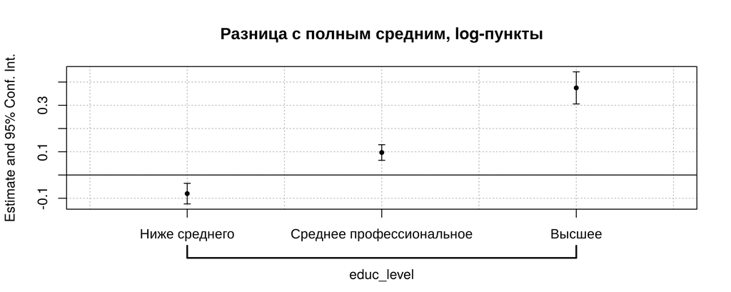

«Год обучения» усредняет очень разные годы: 9-й класс и 5-й курс. Категории честнее, когда шкала не интервальная.

## Четыре стандартные ошибки одной модели

```r
m <- feols(log_wage ~ higher_ed + female + experience + exp2 | year, data = d_ed)
etable(m, m, m, m, vcov = list("iid", "hetero", ~psu, ~idind), keep = "higher_ed",
       depvar = FALSE, drop.section = "fixef", fitstat = ~ n,
       headers = c("iid", "робастные", "psu", "idind"))
```

|  | m | m | m | m |
| --- | --- | --- | --- | --- |
|  | iid | робастные | psu | idind |
| higher_ed | 0.344*** (0.005) | 0.344*** (0.005) | 0.344*** (0.032) | 0.344*** (0.010) |
| ____________ | ________________ | ________________ | ________________ | ________________ |
| S.E. type | IID | Heterosked.-rob. | by: psu | by: idind |
| Observations | 79,068 | 79,068 | 79,068 | 79,068 |

# Как ошибаются

## Семь ошибок с регрессией

1. Читают 0.3 в лог-модели как «30 %» (на самом деле 35 %), а 1.0 — как «100 %» (172 %)
2. Сравнивают коэффициенты между моделями с разными контролями и объявляют «робастность»
3. Считают $R^2$ мерой причинной валидности: модель с $R^2 = 0.9$ может быть целиком про отбор
4. Кластеризуют «как получится» или не кластеризуют вовсе
5. Интерпретируют все коэффициенты (Table 2 fallacy)
6. Экстраполируют: контроль за возрастом линейно там, где возрастные группы не пересекаются
7. Условие на `wage > 0` — отбор по исходу (лекция 3)

## Чек-лист регрессии для оценки эффекта

- Набор контролей выведен из графа, не из «что было в данных»
- Ни один контроль не измерен после воздействия
- Функциональная форма: логарифм для денег, категории для шкал, квадрат для возраста/опыта
- Кластер — по уровню назначения или отбора
- Эффект переведён в понятные единицы (`avg_comparisons`)
- Показан путь коэффициента: что меняет каждый контроль и почему
- Есть оценка, насколько сильным должен быть пропущенный конфаундер, чтобы «убить» результат (лекция 17)

# Мини-задача

## Задание к следующему занятию

1. Оцените эффект **официального оформления** (`official`) на зарплату: наивно, с контролями из вашего DAG, с фиксированными эффектами площадки и года. Постройте путь коэффициента
2. Воспроизведите FWL для этого эффекта и нарисуйте binscatter остатков
3. Посчитайте регрессионные веса по группам «образование × поселение». Какие группы определяют оценку? Есть ли группы с весом ≈ 0?
4. Переведите коэффициент в проценты зарплаты через `avg_comparisons()`; сравните с $e^{\tau}-1$

# Литература

## Что прочитать

- Angrist J., Pischke J.-S. *Mostly Harmless Econometrics*, гл. 3 — регрессия как условное среднее, веса, OVB
- Cunningham S. *The Mixtape*, гл. 2 «Probability and Regression Review» — FWL
- Huntington-Klein N. *The Effect*, гл. 13 «Regression»
- Cinelli C., Hazlett C. (2020). Making Sense of Sensitivity. *JRSS-B* — формула OVB как инструмент
- Abadie A., Athey S., Imbens G., Wooldridge J. (2023). When Should You Adjust Standard Errors for Clustering? *QJE*
- Пакеты: [`fixest`](https://lrberge.github.io/fixest/), [`marginaleffects`](https://marginaleffects.com/), [`modelsummary`](https://modelsummary.com/)

Каузальный анализ в R · RLMS-HSE · К. Аванесян

← К программе курса